# CS 372/472 & LRN_SCI 372/472

Networks

Prof. Connor Bain

connor.bain@northwestern.edu

May 7, 2026

## Logistical Stuff

**THERE ARE TWO ASSIGNMENTS TO WORK ON THIS WEEK**

**Exercise 6**

- Normal programming assignment but shorter than usual
- Asks you to think about links and networks (which we’ll talk more about Thursday)
- Is due on **SUNDAY at 11:59pm** via Canvas.

**Final Project Proposal**

- Asks you to concretize your project idea and start thinking about the design of your model.
- Is due on **MONDAY at 11:59pm** via Canvas.
  - You should also plan to print 5 printouts of your proposal to bring to class on Tuesday, May 12th for peer review.

## Model towards a question

> “All models are wrong, but some are useful.” (Box 1979)
- Don’t add parameters / content **just because it’s more realistic.**
- Instead, add **only if it helps us answer our question.**

## Advantages of Simplicity

- Helps confirm the mechanisms you modeled are actually necessary
- Makes it easier to understand the model and its behavior
- Facilitates *verification* of the model (i.e., confirming that the model is implemented correctly and behaves as intended)
- Facilitates *validation* of the model (i.e., comparing the model’s behavior to real-world data)

## Features of ABM

- Agents enable focus on individuals (e.g. particles, humans, cars, etc.) and their interactions
- Highlights connections between micro and macro
- The spatial structure of the model is distinctly represented (as opposed to EBM)
- Foregrounds mechanisms and locality
- Easily accommodates stochasticity and heterogeneity
- Reduces problems of “mean field” averaging and can create more sensitive systems

## Spatial Environments in ABM

### How do we model the spatial environment in which agents interact?

- A *discrete* environment is one in which space is represented as a grid of cells (e.g., NetLogo’s world).
- A *continuous* environment is one in which space is represented as a continuous plane (e.g., Repast Simphony’s space).

## Discrete Environments

- In a discrete environment, agents occupy cells in a grid and interact with other agents in neighboring cells.
- The connectivity structure of the environment can be defined by the neighborhood of cells (e.g., Moore neighborhood, von Neumann neighborhood).
- The **topology** of the environment can be defined by its edges
- And by its **lattice** structure,.

## Lattices for Discrete Environments

- We’ve been using a **square lattice** in our models, where agents occupy cells in a square grid and interact with their neighbors.

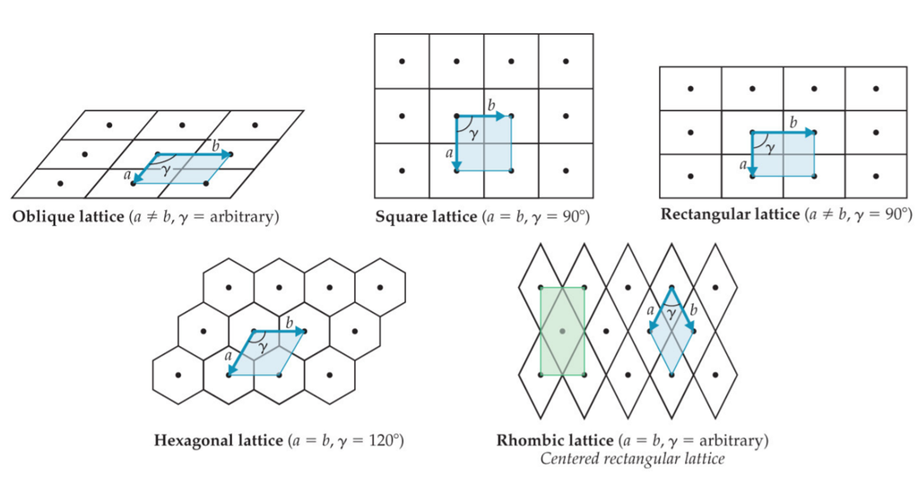

Lattice Examples

## Continuous Environments

- Most of our modeled environments have been discrete
- If our turtles move “patch by patch”, then are turtles movements are also discrete

```
forward patch-size ; (by default 1)
```

- However if we move our turtles by a non-multiple of the `patch-size`, then we are simultaneously modeling discrete and continuous space

```
forward 0.1 ; when patch-size isn't 1
```

- Other modeling environments (e.g., Repast Simphony) are designed around continuous space

## Boundary Conditions

**Note**

A **topology** is a class of environments with the same connectivity structure.

- Bounded Topology - bounded within x and y
- Toroidal Topology - wraps around in x and y
- Infinite Topology - no bounds

# But are humans connected like this these days?

## Connections are different these days

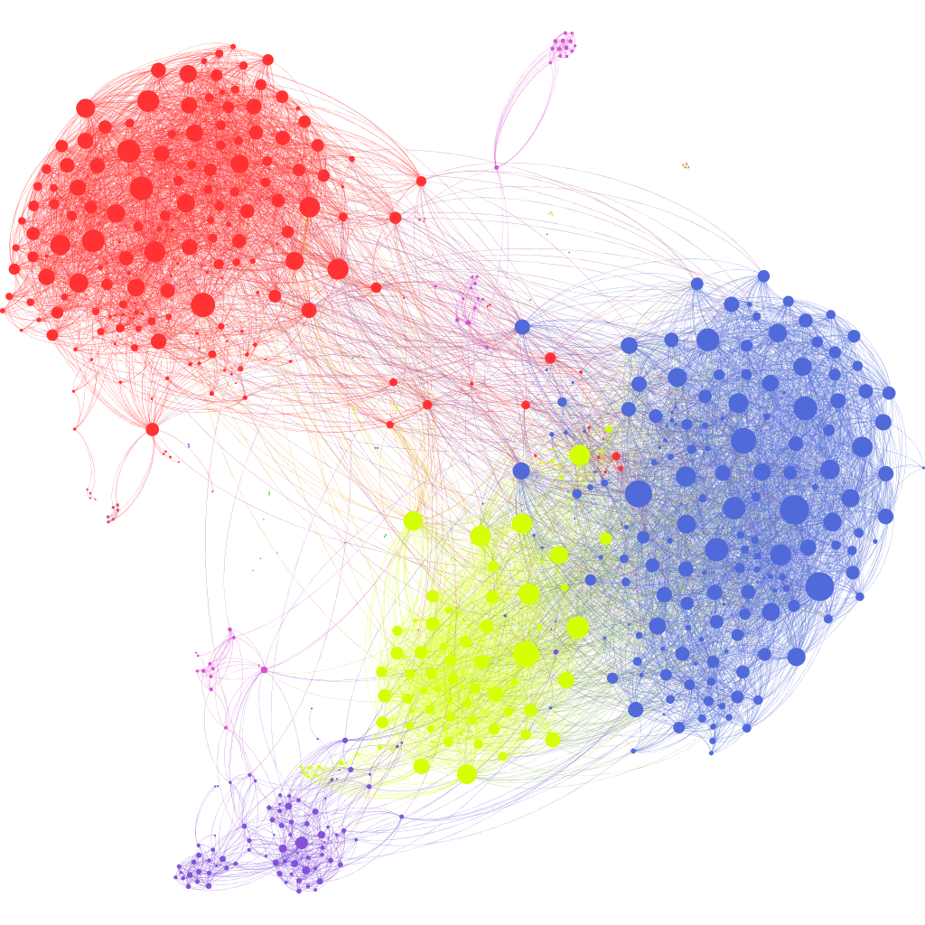

Social Network Graph

## Network Theory

- A **network** is a collection of nodes and edges that represent relationships between entities.

> A **graph** is a mathematical representation of a network, where nodes are represented as *vertices* and *edges* are represented as lines connecting the vertices.
- **Network theory** is the study of how networks are structured and how they function, including concepts such as centrality, clustering, and community detection.

## The Bridges of Königsberg

- Can we plan a walk across the city where we cross each bridge *exactly once*?

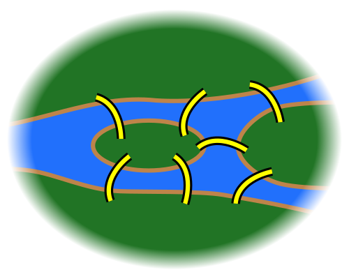

Figure 2

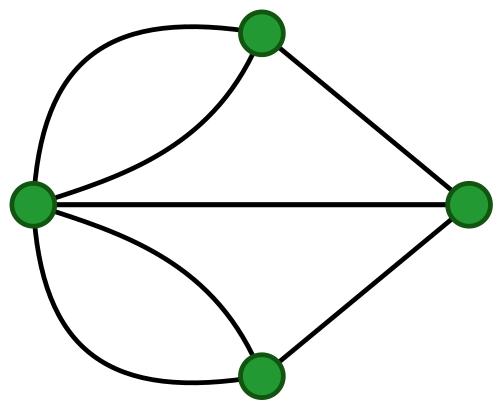

Figure 3

## Basic Terminology

- In NetLogo, we call these connections `links` (just like in network theory)
  - Our `nodes` can be any other agents (i.e. `turtles`, `patches`)
- The degree of a node is how many links it has
- A path is a collection of links that connect two nodes
- The length of a path is how many links in the path
- The clustering coefficient of a node is the ratio of existing links connecting a node’s neighbors to each other to the maximum possible number of such links.

## Network Properties

- The average path length of a network is the average length of the shortest path between all each pair of nodes.
- The clustering coefficient of a network is the average clustering coefficient of every node

## Clustering Coefficient

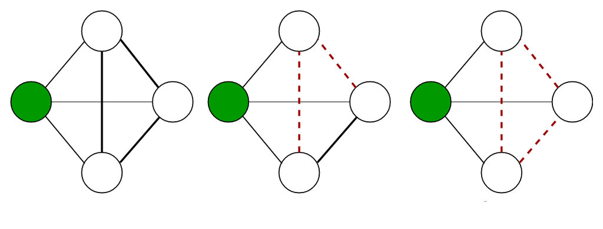

Demo

## Clustering Coefficient

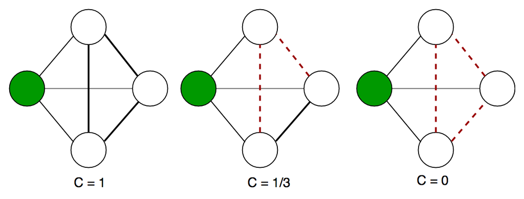

Demo

## Famous Networks Over Time

- Erdos-Renyi random networks (1959)
  - Giant component
- Six degrees of separation (1967)
  - Stanley Milgram’s experiment
- Small world networks (1998)
  - Watts & Strogatz: impact of a few random rewirings
- Scale-free networks (1999)
  - Preferential attachment Barabasi & Albert

## Erdös-Renyi Random Network

A randomized algorithm for generating networks. About the simplest formation model possible.

- Begin with `n` isolated vertices, no edges
- Add edges gradually, one at a time
- Edges are added in a random, unbiased fashion

## The Small World Experiment

- Ever heard the notion “it’s a small world”?
- It comes from an experiment! Travers and Milgram (1977)
- The [Six Degrees of Separation](https://www.sixdegreesofwikipedia.com) is a great example of this

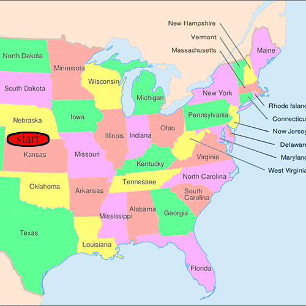

Demo

# But how can we use this to inform ABM design?

## The Bass Model

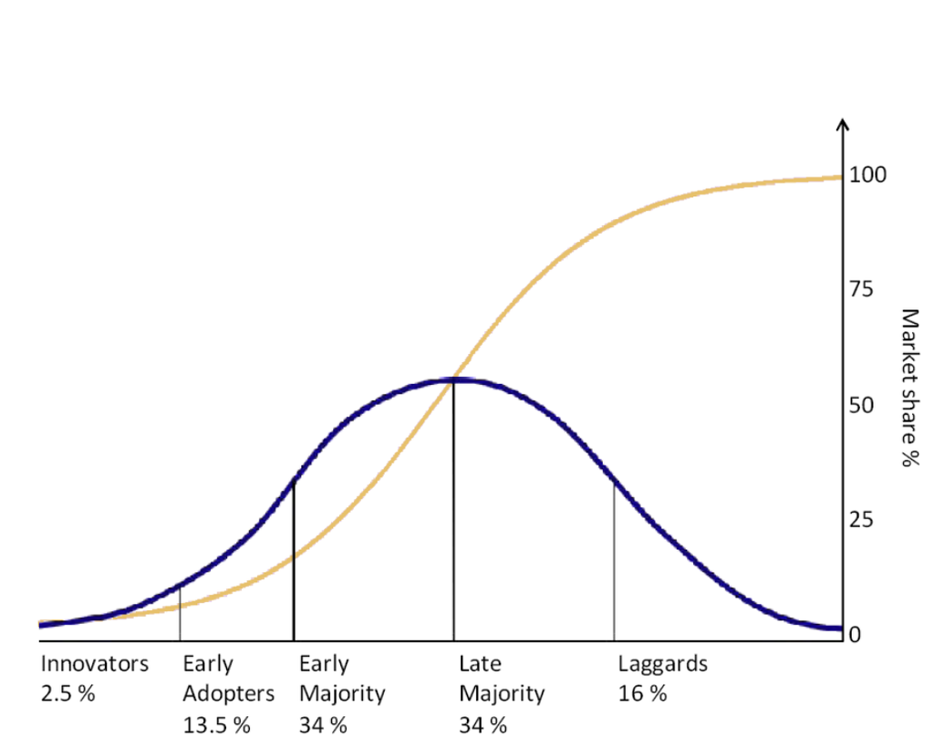

Typical Pattern of Innovation Diffusion

## How could we use ABM to explore this?

> RQ: “What agent-based model will facilitate exploration of patterns of information diffusion?”

or more specifically to replicate a reference pattern

> RQ: “What agent dynamics replicate the general patterns of information diffusion?”

## Model Design

- The `agents` will be users
- Properties: have I adopted the information?
- Behaviors: possible adoption of information
- Environment: initially random network
- Parameters
  - Number of agents
  - Structure of the network
  - Broadcast Influence / Social Influence
- Time Step
  - Decide whether or not to adopt
- Measures: adoption over time

## References

Box, George EP. 1979. “Robustness in the Strategy of Scientific Model Building.” In *Robustness in Statistics*. Elsevier.

Travers, Jeffrey, and Stanley Milgram. 1977. “An Experimental Study of the Small World Problem.” In *Social Networks*. Elsevier.